# Исследование объявлений о продаже квартир в Санкт-Петербурге и области

**Анализ расстояния до ближайшего аэропорта**

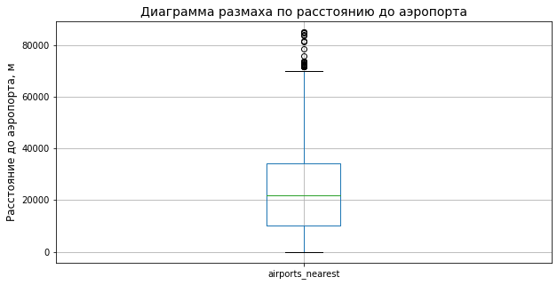

```python
#построение диаграммы размаха
df.boxplot(column=['airports_nearest'], figsize=(10,5), grid=True)
plt.title(f'Диаграмма размаха по расстоянию до аэропорта', fontsize = 14)
plt.ylabel('Расстояние до аэропорта, м', fontsize = 12)
plt.show()
```

В соответствии с диграммой размаха, квартиры большинство квартир расположены на расстоянии до 64000 метров от аэропорта

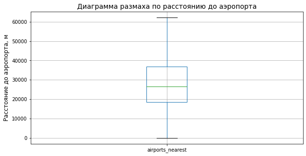

```python
#построение диаграммы размаха и отсечение квартир c удаленностью от аэропорта до 64 км
good_df = df.query('airports_nearest < 64000 & city_centers_nearest != 0')
good_df.boxplot(column=['airports_nearest'], figsize=(10,5), grid=True)
plt.title(f'Диаграмма размаха по расстоянию до аэропорта', fontsize = 14)
plt.ylabel('Расстояние до аэропорта, м', fontsize = 12)
plt.show()
```

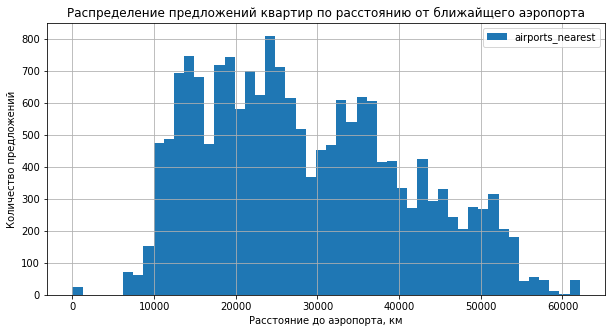

```python
#сортировка и построение гистограммы
good_df.sort_values(by='airports_nearest', ascending=True).plot(kind='hist', y='airports_nearest', bins=50, figsize=(10,5), grid=True)

plt.title('Распределение предложений квартир по расстоянию от ближайщего аэропорта')
plt.xlabel('Расстояние до аэропорта, км')
plt.ylabel('Количество предложений')
plt.show()
```

**Краткий вывод:** Как видно из гистограммы пик предложений приходится на расстоянии от 12 до 27 км. Далее следует тренд на снижение предложений.

**Анализ расстояния до ближайшего парка**

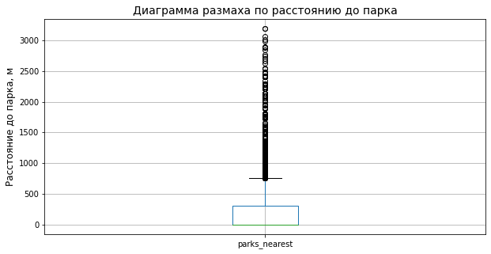

```python
#построение диаграммы размаха
df.boxplot(column=['parks_nearest'], figsize=(10,5), grid=True)
plt.title(f'Диаграмма размаха по расстоянию до парка', fontsize = 14)
plt.ylabel('Расстояние до парка, м', fontsize = 12)
plt.show()
```

В соответствии с диграммой размаха, большинство квартир расположены на расстоянии до 1000 метров от парка

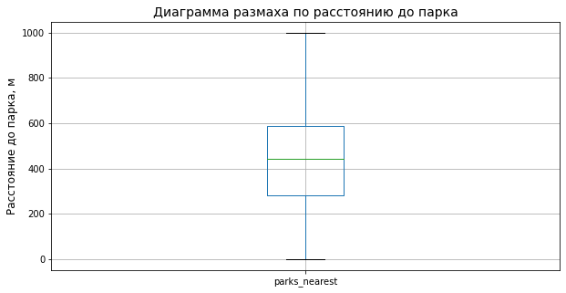

```python
#построение диаграммы размаха и отсечение квартир c удаленностью от парка до 1000 м
good_df = df.query('parks_nearest < 1000 & parks_nearest != 0')
good_df.boxplot(column=['parks_nearest'], figsize=(10,5), grid=True)
plt.title(f'Диаграмма размаха по расстоянию до парка', fontsize = 14)
plt.ylabel('Расстояние до парка, м', fontsize = 12)
plt.show()
```

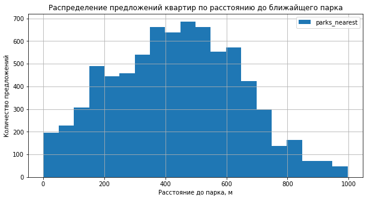

```python
#сортировка и построение гистограммы
good_df.sort_values(by='parks_nearest', ascending=True).plot(kind='hist', y='parks_nearest', bins=20, figsize=(10,5), grid=True)

plt.title('Распределение предложений квартир по расстоянию до ближайщего парка')
plt.xlabel('Расстояние до парка, м')
plt.ylabel('Количество предложений')
plt.show()
```

**Краткий вывод:** Наибольшее предложений по прадажам для квартир на удаленности от парка порядка 380 - 650 метров.

**Анализ дня и месяца публикации объявления**

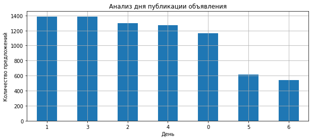

```python
#построение барплота
good_df['weekday_exposition'].value_counts().plot(kind='bar', x='weekday_exposition', figsize=(10,4), grid=True)
plt.title('Анализ дня публикации объявления')
plt.xlabel('День')
plt.xticks(rotation=0)
plt.ylabel('Количество предложений')
plt.show()
```

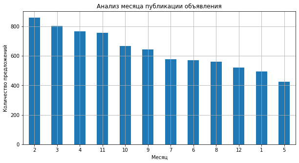

```python
#построение барплота
good_df['monht_exposition'].value_counts().plot(kind='bar', x='monht_exposition', figsize=(10,5), grid=True)

plt.title('Анализ месяца публикации объявления')
plt.xlabel('Месяц')
plt.xticks(rotation=0)
plt.ylabel('Количество предложений')
plt.show()
```

**Краткий вывод:** По результатам проведенного анализа можно отметить, что чаше всего объявления публикуют в четверг и вторник. В выходные, ожидаемое, размещений меньше. Если рассматривать информацию по месяцам, то больше всего объявлений размещаются в феврале - апреле и ноябре. Меньше всего объевления в январе и мае, вероятно из-за большого количества праздников.

**Срок продажи квартиры**

```python
good_df.head(15)
```

|  | total_images | last_price | total_area | first_day_exposition | rooms | ceiling_height | floors_total | living_area | floor | is_apartment | studio | open_plan | kitchen_area | balcony | locality_name | airports_nearest | city_centers_nearest | parks_around_3000 | parks_nearest | ponds_around_3000 | ponds_nearest | days_exposition | price_sq_metrs | weekday_exposition | monht_exposition | year_exposition | floor_info | city_centers_nearest_km |
| --- | --- | --- | --- | --- | --- | --- | --- | --- | --- | --- | --- | --- | --- | --- | --- | --- | --- | --- | --- | --- | --- | --- | --- | --- | --- | --- | --- | --- |
| 0 | 20 | 13000000.0 | 108.0 | 2019-03-07 | 3 | 2.70 | 16 | 51.0 | 8 | False | False | False | 25.0 | 0 | Санкт-Петербург | 18863 | 16028 | 1 | 482 | 2 | 755 | NaN | 120370.37 | 3 | 3 | 2019 | другой | 16 |
| 2 | 10 | 5196000.0 | 56.0 | 2015-08-20 | 2 | 2.70 | 5 | 34.3 | 4 | False | False | False | 8.3 | 0 | Санкт-Петербург | 21741 | 13933 | 1 | 90 | 2 | 574 | 558.0 | 92785.71 | 3 | 8 | 2015 | другой | 13 |
| 3 | 0 | 64900000.0 | 159.0 | 2015-07-24 | 3 | 2.70 | 14 | NaN | 9 | False | False | False | 0.0 | 0 | Санкт-Петербург | 28098 | 6800 | 2 | 84 | 3 | 234 | 424.0 | 408176.10 | 4 | 7 | 2015 | другой | 6 |
| 4 | 2 | 10000000.0 | 100.0 | 2018-06-19 | 2 | 3.03 | 14 | 32.0 | 13 | False | False | False | 41.0 | 0 | Санкт-Петербург | 31856 | 8098 | 2 | 112 | 1 | 48 | 121.0 | 100000.00 | 1 | 6 | 2018 | другой | 8 |
| 10 | 5 | 5050000.0 | 39.6 | 2017-11-16 | 1 | 2.67 | 12 | 20.3 | 3 | False | False | False | 8.5 | 0 | Санкт-Петербург | 38357 | 13878 | 1 | 310 | 2 | 553 | 137.0 | 127525.25 | 3 | 11 | 2017 | другой | 13 |
| 13 | 20 | 3550000.0 | 42.8 | 2017-07-01 | 2 | 2.56 | 5 | 27.0 | 5 | False | False | False | 5.2 | 1 | Петергоф | 37868 | 33058 | 1 | 294 | 3 | 298 | 366.0 | 82943.93 | 5 | 7 | 2017 | последний | 33 |
| 15 | 16 | 4650000.0 | 39.0 | 2017-11-18 | 1 | 2.70 | 14 | 20.5 | 5 | False | False | False | 7.6 | 1 | Санкт-Петербург | 12900 | 14259 | 1 | 590 | 1 | 296 | 19.0 | 119230.77 | 5 | 11 | 2017 | другой | 14 |
| 16 | 11 | 6700000.0 | 82.0 | 2017-11-23 | 3 | 3.05 | 5 | 55.6 | 1 | False | False | False | 9.0 | 0 | Санкт-Петербург | 22108 | 10698 | 3 | 420 | 0 | 0 | 397.0 | 81707.32 | 3 | 11 | 2017 | первый | 10 |
| 18 | 8 | 3250000.0 | 31.0 | 2017-01-27 | 1 | 2.50 | 5 | 19.4 | 2 | False | False | False | 5.6 | 1 | Санкт-Петербург | 44060 | 10842 | 1 | 759 | 0 | 0 | 168.0 | 104838.71 | 4 | 1 | 2017 | другой | 10 |
| 21 | 13 | 3200000.0 | 31.6 | 2018-03-14 | 1 | 2.70 | 5 | 16.9 | 2 | False | False | False | 5.7 | 1 | Санкт-Петербург | 36064 | 9722 | 1 | 248 | 0 | 0 | 310.0 | 101265.82 | 2 | 3 | 2018 | другой | 9 |
| 23 | 11 | 2950000.0 | 32.0 | 2016-10-29 | 1 | 2.60 | 9 | 17.7 | 9 | False | False | False | 6.1 | 0 | Санкт-Петербург | 15414 | 14211 | 2 | 517 | 1 | 190 | 615.0 | 92187.50 | 5 | 10 | 2016 | последний | 14 |
| 24 | 8 | 6500000.0 | 97.2 | 2015-10-31 | 2 | 2.70 | 3 | 46.5 | 1 | False | False | False | 19.6 | 0 | Санкт-Петербург | 20052 | 2336 | 3 | 411 | 3 | 124 | 265.0 | 66872.43 | 5 | 10 | 2015 | первый | 2 |
| 27 | 20 | 7100000.0 | 70.0 | 2017-05-12 | 3 | 2.60 | 17 | 49.0 | 11 | False | False | False | 9.2 | 0 | Санкт-Петербург | 29197 | 11456 | 2 | 452 | 1 | 779 | 151.0 | 101428.57 | 4 | 5 | 2017 | другой | 11 |
| 29 | 9 | 8600000.0 | 100.0 | 2016-04-09 | 3 | 2.70 | 19 | 52.0 | 15 | False | False | False | 11.0 | 0 | Санкт-Петербург | 30394 | 11526 | 1 | 532 | 1 | 896 | 125.0 | 86000.00 | 5 | 4 | 2016 | другой | 11 |
| 36 | 13 | 3790000.0 | 45.0 | 2017-01-25 | 2 | 2.70 | 9 | 27.0 | 9 | False | False | False | 6.3 | 2 | Санкт-Петербург | 49574 | 16461 | 1 | 459 | 0 | 0 | 139.0 | 84222.22 | 2 | 1 | 2017 | последний | 16 |

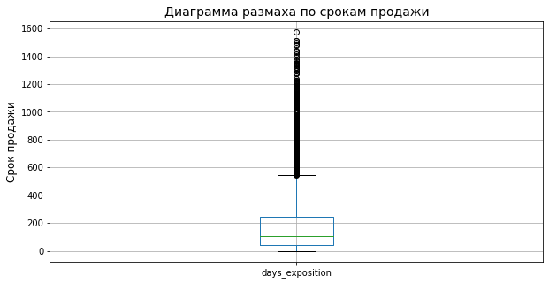

```python
#построение диаграммы размаха
good_df.boxplot(column=['days_exposition'], figsize=(10,5), grid=True)
plt.ylabel('Срок продажи')
plt.title(f'Диаграмма размаха по срокам продажи', fontsize = 14)
plt.ylabel('Срок продажи', fontsize = 12)
plt.show()
```

```python
good_df['days_exposition'].describe().round(2)
```

```
count    6555.00
mean      192.70
std       232.08
min         1.00
25%        45.00
50%       104.00
75%       246.00
max      1572.00
Name: days_exposition, dtype: float64
```

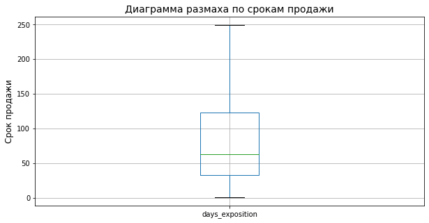

```python
#построение диаграммы размаха и отсечение квартир cо сроком продажи более 250 дней
good_df = df.query('days_exposition < 250')
good_df.boxplot(column=['days_exposition'], figsize=(10,5), grid=True)
plt.title(f'Диаграмма размаха по срокам продажи', fontsize = 14)
plt.ylabel('Срок продажи', fontsize = 12)
plt.show()
```

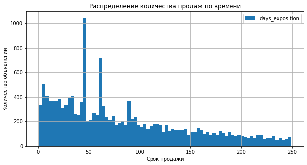

```python
good_df.plot(kind='hist',y='days_exposition', bins=80, figsize=(10,5), grid=True)

plt.title('Распределение количества продаж по времени')
plt.xlabel('Срок продажи')
plt.ylabel('Количество объявлений')
plt.show()
```

**Факторы, влияющие на стоимость квартиры**

*Зависимость стоимости от площади квартиры<*

```
            total_area  last_price
total_area    1.000000    0.628364
last_price    0.628364    1.000000
```

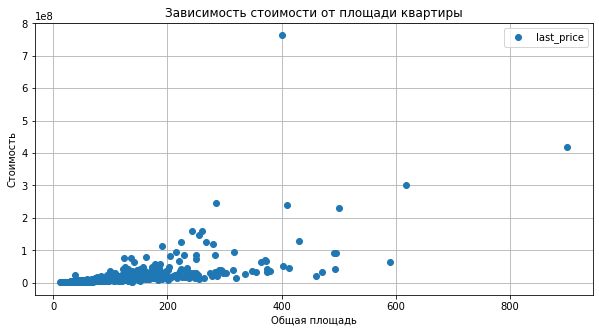

```python
#построение диаграммы разброса и корреляции при помощи сводной таблицы

good_df.pivot_table(index='total_area', values='last_price').plot(grid=True, style='o', figsize=(10, 5))

plt.title('Зависимость стоимости от площади квартиры')
plt.xlabel('Общая площадь')
plt.ylabel('Стоимость')
print(good_df.pivot_table(index='total_area', values=['last_price']).reset_index().corr())
```

**Краткий вывод:** Как видно из графика стоимость жилья и его общей площади имеют заметную корреляцию (0,63). Зависимость по данным параметрам есть. Чем больше площадь, тем соответсвенно выше стоимость.

*Зависимость стоимости от жилой площади квартиры*

```
             living_area  last_price
living_area     1.000000    0.633682
last_price      0.633682    1.000000
```

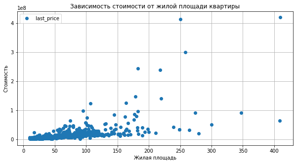

```python
#построение диаграммы разброса и корреляции при помощи сводной таблицы
good_df.pivot_table(index='living_area', values='last_price').plot(grid=True, style='o', figsize=(10, 5))

plt.title('Зависимость стоимости от жилой площади квартиры')
plt.xlabel('Жилая площадь')
plt.ylabel('Стоимость')
print(good_df.pivot_table(index='living_area', values=['last_price']).reset_index().corr())
```

**Вывод:** Зависимость стоимости жилья от его жилой площади также показывает заметную зависимость (коэффициент корреляции - 0,63). Это логично, так как показательно примерно такой же, как и общей площадь.

*Зависимость стоимости от площади кухни*

```
              kitchen_area  last_price
kitchen_area      1.000000    0.587272
last_price        0.587272    1.000000
```

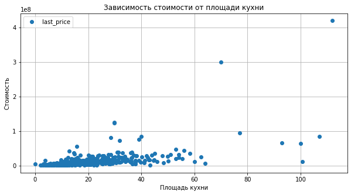

```python
#построение диаграммы разброса и корреляции при помощи сводной таблицы
good_df.pivot_table(index='kitchen_area', values='last_price').plot(grid=True, style='o', figsize=(10, 5))

plt.title('Зависимость стоимости от площади кухни')
plt.xlabel('Площадь кухни')
plt.ylabel('Стоимость')
print(good_df.pivot_table(index='kitchen_area', values=['last_price']).reset_index().corr())
```

**Краткий вывод:** Зависимость стоимости жилья от площади кухни имеет заметную корреляцию (0,59). Зависимость по-прежнему есть сохраняется.

*Зависимость стоимости от количества комнат*

```
               rooms  last_price
rooms       1.000000    0.326797
last_price  0.326797    1.000000
```

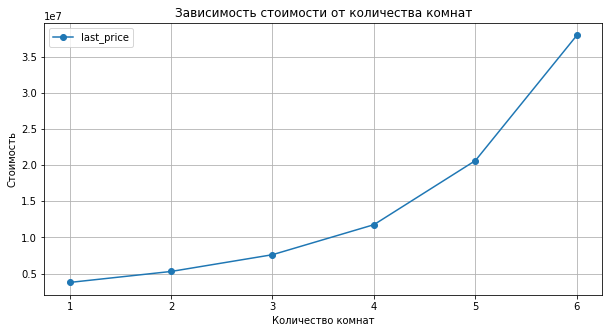

```python
#построение диаграммы разброса и корреляции при помощи сводной таблицы
good_df.query('rooms > 0 & rooms < 7').pivot_table(index='rooms', values='last_price').plot(grid=True, style='o-', figsize=(10, 5))

plt.title('Зависимость стоимости от количества комнат')
plt.xlabel('Количество комнат')
plt.ylabel('Стоимость')
print(good_df.pivot_table(index='rooms', values=['last_price']).reset_index().corr())
```

**Краткий вывод:** Зависимость стоимости жилья от количества комнат имеет умеренную корреляцию - 0,33. Чем больше комнат, тем дороже жилье. Это также логично, так как в данном случае и больше общая площадь.

*Зависимость стоимости от типа этажа*

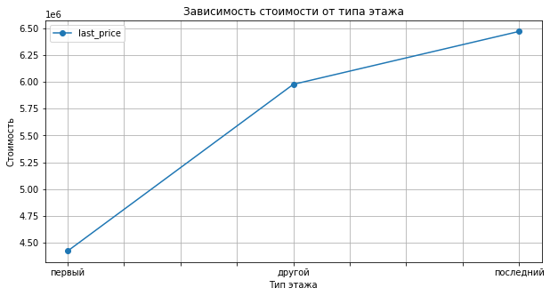

```python
#построение графика при помощи сводной таблицы
good_df.pivot_table(index='floor_info', values='last_price').sort_values(by='last_price', ascending=True).plot(grid=True, style='o-', figsize=(10, 5))

plt.title('Зависимость стоимости от типа этажа')
plt.xlabel('Тип этажа')
plt.ylabel('Стоимость')
plt.show()
```

**Вывод:** Как видно из графика самая дешевая стоимость у квартир на первых этаж. Можно предположить, что чем выше этаж, тем больше стоимость жилья.

*Зависимость стоимости от даты размещения объявления*

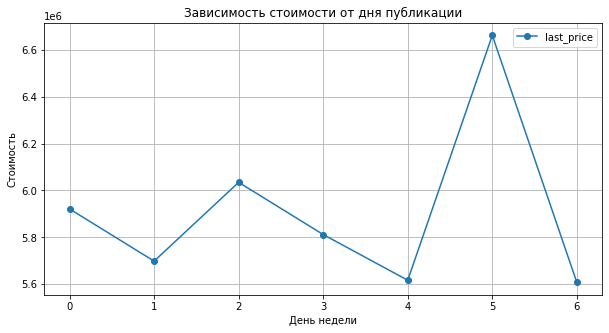

```python
good_df.pivot_table(index='weekday_exposition', values='last_price').plot(grid=True, style='o-', figsize=(10, 5))

plt.title('Зависимость стоимости от дня публикации')
plt.xlabel('День недели')
plt.ylabel('Стоимость')
plt.show()
```

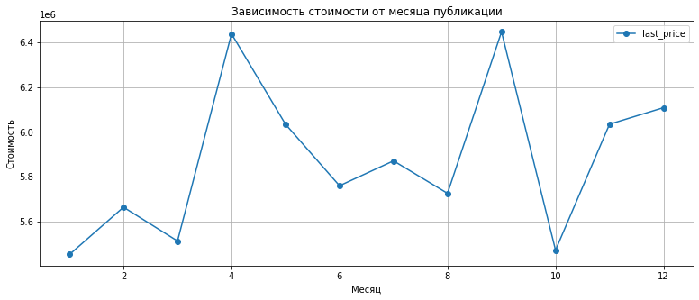

```python
good_df.pivot_table(index='monht_exposition', values='last_price').plot(grid=True, style='o-', figsize=(13, 5))

plt.title('Зависимость стоимости от месяца публикации')
plt.xlabel('Месяц')
plt.ylabel('Стоимость')
plt.show()
```

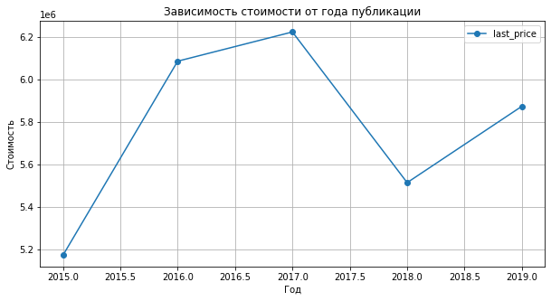

```python
good_df.pivot_table(index='year_exposition', values='last_price').plot(grid=True, style='o-', figsize=(10, 5))

plt.title('Зависимость стоимости от года публикации')
plt.xlabel('Год')
plt.ylabel('Стоимость')
plt.show()
```

*Подсчет средней цены одного квадратного метра в 10 населённых пунктах с наибольшим числом объявлений*

```python
#подготовка сводной таблицы
df_top_ten = df.pivot_table(index='locality_name', values='last_price', aggfunc='count').sort_values(by='last_price', ascending=False).head(10)
df_top_ten.columns=['count adds']

df_top_ten['price_sq_metrs_median'] = df.pivot_table(index='locality_name', values='price_sq_metrs', aggfunc='median')
df_top_ten['price_sq_metrs_min'] = df.pivot_table(index='locality_name', values='price_sq_metrs', aggfunc='min')
df_top_ten['price_sq_metrs_max'] = df.pivot_table(index='locality_name', values='price_sq_metrs', aggfunc='max')
df_top_ten
```

| locality_name | count adds | price_sq_metrs_median | price_sq_metrs_min | price_sq_metrs_max |
| --- | --- | --- | --- | --- |
| Санкт-Петербург | 15641 | 104790.420 | 15345.27 | 1907500.00 |
| Мурино | 586 | 86250.375 | 50000.00 | 138580.25 |
| Кудрово | 469 | 95588.240 | 54160.35 | 160401.00 |
| Шушары | 439 | 76829.270 | 47700.42 | 147826.09 |
| Всеволожск | 397 | 65789.470 | 31400.00 | 640422.35 |
| Пушкин | 369 | 100000.000 | 59836.07 | 256521.74 |
| Колпино | 338 | 74723.745 | 47957.37 | 125000.00 |
| Парголово | 327 | 91642.860 | 39205.96 | 138522.43 |
| Гатчина | 307 | 67796.610 | 10507.25 | 146315.79 |
| Выборг | 235 | 58307.690 | 18750.00 | 107473.12 |

**Определение цены за каждый км от центра Санкт-Петербурга**

```python
spb = (df
      .query('locality_name == "Санкт-Петербург"')
      .pivot_table(index='city_centers_nearest_km', values=['price_sq_metrs'], aggfunc={'count','mean'})
      .round(2).reset_index())
spb.columns = spb.columns.droplevel(0)
spb = spb.rename(columns={'count':'кол-во', 'mean':'ср. цена'})
spb.head(10)
```

|  |  | кол-во | ср. цена |
| --- | --- | --- | --- |
| 0 | 0 | 146 | 174708.37 |
| 1 | 1 | 240 | 166603.76 |
| 2 | 2 | 307 | 146662.86 |
| 3 | 3 | 524 | 129526.93 |
| 4 | 4 | 903 | 137413.43 |
| 5 | 5 | 768 | 146978.31 |
| 6 | 6 | 470 | 152277.89 |
| 7 | 7 | 406 | 141404.91 |
| 8 | 8 | 666 | 119819.21 |
| 9 | 9 | 687 | 110187.82 |

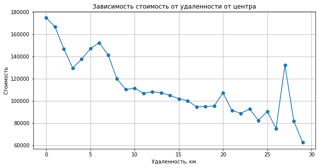

```python
spb['ср. цена'].plot(grid=True, style='o-', figsize=(10, 5))
plt.title('Зависимость стоимость от удаленности от центра')
plt.xlabel('Удаленность, км.')
plt.ylabel('Стоимость')
plt.show()
```

**Краткий вывод:** Из проведенного анализа видно, что чем ближе квартира к центру, тем дороже цена среднего квадратного метра. Самая высокая цена - 174 708 руб. Правда выбивается провал по цене на расстоянии 3 км. Также стоит отметить резкий скачок цен в 27 км. от центра (цена - 132 115). Наблюдается несколько всплесков на 20, 23 и 25 км. Возможно такие скачки связаны с типом жилья.

### Общий вывод

*1) В части предобработки данных*  
При анализе массива данных было обнаружено большое число пропущенных значений (по некоторым данным пропуски достигали 20 000). Для устранения пропусков былы применены методы удаления строк (если таких значений не много), замены на 0 (там где это логически возможно и можно объяснить причину пропуска), замену на медианные значения. Пропуски, которые не возможно подменить, были оставлены. Также были привидены в соответствия типы столбцов, были отработаны аномалии (путем правок или удаления). Произведена подмена неявных дубликатов. В результате предобработки данных массив состоял из 23,5 тыс. данных.  
*2) В части анализа заданных параметров*

- наиболешее количество предложений по объявлениям приходится на размер квартир общей площадью от 30 до 45 кв. м. Самое большое количество предложений для квартир с площадью 45 кв.м.;
- больше всего предложений приходится на жилую площадь в диапозоне от 15 до 20 кв. м.;
- самые популярные размеры кухонь держаться в диапазоне 6 - 10 кв. м.;
- наибольшее число предложений со стоимостью квартирт 3,2-5,2 млн руб.;
- больше всего продается одно- или двухкомнатных квартир;
- наиболешее количество предложений для 5 и 10 этажных домов;
- больше всего объявлений на 2 и 3 этажах, и далее на спад;
- больше всего предложений для квартир на расстоянии от 10 до 16 км. от центра;
- пик предложений приходится на расстоянии от 12 до 27 км. от аэропорта;
- наибольшее предложений по прадажам для квартир на удаленности от парка порядка 380 - 650 метров;
- чаше всего объявления публикуют в четверг и вторник. В выходные, ожидаемое, размещений меньше. Меньше всего объевления в январе и мае, вероятно из-зи большого количества праздников.